# 5. Bilingual Study Re-production

# Packages Used

```r
library(tidyverse)         # For data manipulation and visualization
library(readxl)            # For reading Excel files
library(boot)              # For bootstrapping
library(gridExtra)
```

# Data Load

This chunk loads the original Study 4 dataset and a translation table for Indian regions. It then reshapes the data to align English and Hindi response columns, matches language tags, recodes variables, and merges geographic state-level information.

```r
df4 <- read_excel("Data/Extracted_Data/MonetaryIncentives_Study4_RAW_India_deidentified.xlsx")
indian_states <- read_excel("Tables/Translation_Table_India_Regions.xlsx")

# Clean and reshape data to align English and Hindi responses
# Pivot long to bring .E and .H columns into a single column
# Filter to match language responses with column tags
# Recode variables and merge state information (Living_State only)

df4_clean <- df4 %>%
  pivot_longer(cols = matches(".*\\.E$|.*\\.H$"),
               names_pattern = "(.*)\\.(.)",
               names_to = c(".value", "ColumnLanguage")) %>%
  filter((language == "english" & ColumnLanguage == "E") |
         (language == "hindi" & ColumnLanguage == "H")) %>%
  mutate(
    num_total_answers = as.numeric(num_total_answers),
    Incentive = factor(incentive, levels = c("lowpay", "norm"),
                       labels = c("Monetary", "Norm")),
    Language = factor(language, levels = c("english", "hindi"),
                      labels = c("English", "Hindi")),
    HHIncome_Numeric = case_when(
      HHIncome == 1 ~ 125000,
      HHIncome == 2 ~ 375000,
      HHIncome == 3 ~ 750000,
      HHIncome == 4 ~ 1250000,
      HHIncome == 5 ~ 1750000
    ),
    HHIncome = factor(HHIncome,
                      levels = 1:8,
                      labels = c("Income: Less than ₹2.5 lakhs",
                                 "Income: ₹2.5 lakhs to ₹4.9 lakhs",
                                 "Income: ₹5 lakhs to ₹9.9 lakhs",
                                 "Income: ₹10 lakhs to ₹14.9 lakhs",
                                 "Income: ₹15 lakhs and above",
                                 "Income: Not working",
                                 "Income: Student",
                                 "Income: Retired"))) %>%
  left_join(indian_states, by = c("Living_State" = "Index")) %>%
  mutate(Living_State = `State/UT`) %>%
  select(-`State/UT`)

# Subset only monetary incentive condition
df4_monetary <- df4_clean %>% filter(Incentive == "Monetary")
```

# SES Analysis

This section compares English vs. Hindi performance differences by subjective SES. It creates a median split for SES, calculates groupwise means, and then uses bootstrapping to compute standard errors around those means.

```r
df_ses <- df4_monetary %>%
  mutate(Median_Split_SES = ifelse(SubjectiveSES <= median(SubjectiveSES, na.rm = TRUE),
                                   "Below Median", "Above Median"))

# Function to calculate bootstrapped SEs
bootstrap_se <- function(data, indices) {
  d <- data[indices, ]
  mean(d$diff, na.rm = TRUE)
}

# Calculate true group means and differences
ses_diff <- df_ses %>%
  filter(!is.na(Median_Split_SES)) %>%
  group_by(Median_Split_SES, Language) %>%
  summarise(mean_ans = mean(num_total_answers, na.rm = TRUE), .groups = "drop") %>%
  pivot_wider(names_from = Language, values_from = mean_ans) %>%
  mutate(diff = English - Hindi)

# Bootstrap only SEs
ses_boot <- df_ses %>%
  filter(Language %in% c("English", "Hindi")) %>%
  group_split(Median_Split_SES) %>%
  map_dfr(function(group) {
    cat_name <- unique(group$Median_Split_SES)
    group_wide <- group %>%
      group_by(Language) %>%
      summarise(mean = mean(num_total_answers, na.rm = TRUE), .groups = "drop") %>%
      pivot_wider(names_from = Language, values_from = mean)
    true_diff <- group_wide$English - group_wide$Hindi
    b <- boot(data = group, statistic = function(d, i) {
      sample <- d[i, ]
      mean(sample$num_total_answers[sample$Language == "English"], na.rm = TRUE) -
        mean(sample$num_total_answers[sample$Language == "Hindi"], na.rm = TRUE)
    }, R = 1000)
    tibble(
      Median_Split_SES = cat_name,
      diff = true_diff,
      se_diff = sd(b$t)
    )
  })
# Ensure factor order
ses_boot <- ses_boot %>%
  filter(!is.na(Median_Split_SES)) %>%
  mutate(Median_Split_SES = factor(Median_Split_SES, levels = c("Below Median", "Above Median")))

# Plot
plot1 <- ggplot(ses_boot, aes(x = Median_Split_SES, y = diff, fill = Median_Split_SES)) +
  geom_bar(stat = "identity", color = "black") +
  geom_errorbar(aes(ymin = diff - se_diff, ymax = diff + se_diff), width = 0.2) +
  geom_hline(yintercept = 0, linetype = "dashed", color = "grey40") +
  scale_fill_manual(values = c("Below Median" = "#a1d99b", "Above Median" = "#006d2c")) +
  theme_minimal() +
  labs(x = "Subjective SES", y = "Mean Difference (English - Hindi)", title = "Mean Difference in Performance by SES")
```

# Testing Statistical Difference for SES

This chunk tests whether the effect of language (English vs. Hindi) on total answers differs significantly between subjective SES groups. We implement a bootstrap procedure to estimate the standard error and 95% confidence interval of the difference-in-differences (DiD) — the gap in language effects between “Above Median” and “Below Median” SES groups. A statistically significant result would indicate that SES moderates the language-performance relationship.

```r
# Filter and prepare data
df_did <- df_ses %>%
  filter(Language %in% c("English", "Hindi"), !is.na(Median_Split_SES))

# Bootstrap function for DiD
did_bootstrap <- function(data, indices) {
  d <- data[indices, ]
  d_above <- d %>% filter(Median_Split_SES == "Above Median")
  d_below <- d %>% filter(Median_Split_SES == "Below Median")

  diff_above <- mean(d_above$num_total_answers[d_above$Language == "English"], na.rm = TRUE) -
                mean(d_above$num_total_answers[d_above$Language == "Hindi"], na.rm = TRUE)

  diff_below <- mean(d_below$num_total_answers[d_below$Language == "English"], na.rm = TRUE) -
                mean(d_below$num_total_answers[d_below$Language == "Hindi"], na.rm = TRUE)

  return(diff_above - diff_below)
}

# Run bootstrap
set.seed(123)
library(boot)
did_result <- boot(data = df_did, statistic = did_bootstrap, R = 1000)

# Confidence interval
did_ci <- boot.ci(did_result, type = "perc")$percent[4:5]

# Output
list(
  diff_in_diff = mean(did_result$t),
  se = sd(did_result$t),
  ci_lower = did_ci[1],
  ci_upper = did_ci[2],
  significant = ifelse(did_ci[1] > 0 | did_ci[2] < 0, "Yes", "No")
)
```

```
$diff_in_diff
[1] -4.538444

$se
[1] 4.165877

$ci_lower
[1] -12.76376

$ci_upper
[1] 3.91209

$significant
[1] "No"
```

# Income Analysis

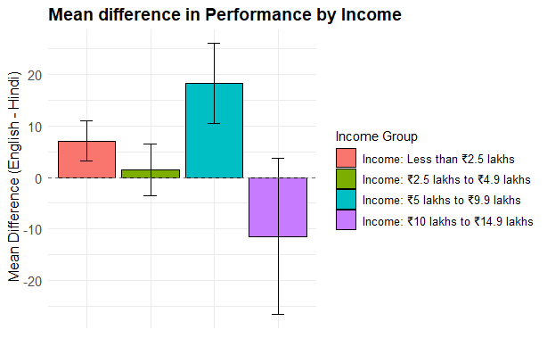

```r
# Exclude non-working/student/retired categories
excluded_levels <- c("Income: Not working", "Income: Student", "Income: Retired", "Income: ₹15 lakhs and above")

df_income <- df4_monetary %>%
  filter(!(HHIncome %in% excluded_levels),
         Language %in% c("English", "Hindi"),
         !is.na(num_total_answers)) %>%
  mutate(HHIncome = factor(HHIncome, ordered = TRUE))

# Define bootstrap_diff function
bootstrap_diff <- function(data, indices) {
  d <- data[indices, ]
  mean(d$num_total_answers[d$Language == "English"], na.rm = TRUE) -
    mean(d$num_total_answers[d$Language == "Hindi"], na.rm = TRUE)
}

# Bootstrap by each income level
income_levels <- levels(df_income$HHIncome)

income_boot <- lapply(income_levels, function(level) {
  group_data <- df_income %>% filter(HHIncome == level)
  if (nrow(group_data) >= 10 && length(unique(group_data$Language)) == 2) {
    # True mean difference
    true_diff <- mean(group_data$num_total_answers[group_data$Language == "English"], na.rm = TRUE) -
      mean(group_data$num_total_answers[group_data$Language == "Hindi"], na.rm = TRUE)

    # Bootstrap SE
    b <- boot(data = group_data, statistic = bootstrap_diff, R = 1000)

    tibble(
      HHIncome = level,
      diff = true_diff,
      se_diff = sd(b$t)
    )
  } else {
    tibble(HHIncome = level, diff = NA, se_diff = NA)
  }
})

plot2_data <- bind_rows(income_boot) %>%
  mutate(HHIncome = factor(HHIncome, levels = income_levels))

# Plot income-wise bootstrapped differences
plot2 <- ggplot(plot2_data, aes(x = HHIncome, y = diff, fill = HHIncome)) +
  geom_bar(stat = "identity", color = "black") +
  geom_errorbar(aes(ymin = diff - se_diff, ymax = diff + se_diff), width = 0.2) +
  geom_hline(yintercept = 0, linetype = "dashed", color = "grey40") +
  theme_minimal() +
  labs(
    x = NULL,  # Removes x-axis label
    y = " Mean Difference (English - Hindi)",
    title = "Mean difference in Performance by Income",
    fill = "Income Group"  # Title for the legend
  ) +
  theme(
    axis.text.x = element_blank(),         # Remove x-axis tick labels
    axis.ticks.x = element_blank(),        # Remove x-axis ticks
    legend.position = "right",             # Move legend to the right
    legend.title = element_text(size = 11),
    legend.text = element_text(size = 10),
    plot.title = element_text(size = 14, face = "bold"),
    axis.text = element_text(size = 11),
    axis.title = element_text(size = 12)
  )

print(plot2)
```

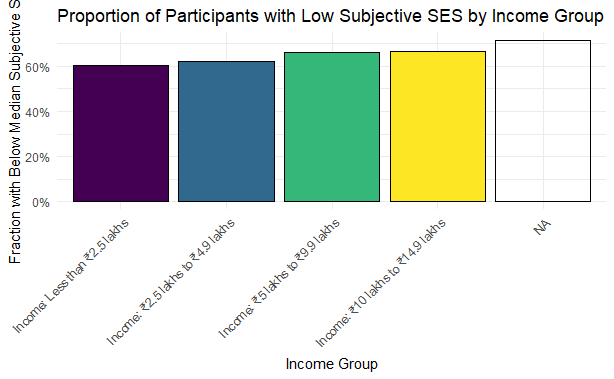

```r
# Recalculate Median_Split_SES in case not inherited
df_ses_income <- df4_monetary %>%
  filter(!(HHIncome %in% excluded_levels),
         !is.na(SubjectiveSES)) %>%
  mutate(Median_Split_SES = ifelse(SubjectiveSES <= median(SubjectiveSES, na.rm = TRUE),
                                   "Below Median", "Above Median"))

# Calculate fraction of each income group in Below Median SES
income_ses_fraction <- df_ses_income %>%
  group_by(HHIncome) %>%
  summarise(
    total = n(),
    below_median = sum(Median_Split_SES == "Below Median"),
    frac_below = below_median / total
  ) %>%
  mutate(HHIncome = factor(HHIncome, levels = levels(df_income$HHIncome), ordered = TRUE))

# Plot
library(ggplot2)

ses_frac_plot <- ggplot(income_ses_fraction, aes(x = HHIncome, y = frac_below, fill = HHIncome)) +
  geom_bar(stat = "identity", color = "black") +
  scale_y_continuous(labels = scales::percent_format()) +
  theme_minimal() +
  labs(
    x = "Income Group",
    y = "Fraction with Below Median Subjective SES",
    title = "Proportion of Participants with Low Subjective SES by Income Group"
  ) +
  theme(
    axis.text.x = element_text(angle = 45, hjust = 1),
    legend.position = "none"
  )

print(ses_frac_plot)
```

# Regional Analysis

This section bootstraps English-Hindi differences by Indian state, grouping small samples as “Other”, and ranks them by distance to the equator.

```r
focus_states <- c("Delhi", "Haryana", "Rajasthan", "Uttar Pradesh", "Bihar")

df_region <- df4_monetary %>%
  mutate(State_Grouped = if_else(Living_State %in% focus_states, Living_State, "Other")) %>%
  filter(Language %in% c("English", "Hindi"), !is.na(num_total_answers))

states <- unique(df_region$State_Grouped)

region_boot <- lapply(states, function(state) {
  data_state <- df_region %>% filter(State_Grouped == state)
  if (length(unique(data_state$Language)) == 2 && nrow(data_state) >= 10) {
    b <- boot(data = data_state, statistic = bootstrap_diff, R = 1000)
    tibble(State = state, diff = mean(data_state$num_total_answers[data_state$Language == "English"], na.rm = TRUE) -
                         mean(data_state$num_total_answers[data_state$Language == "Hindi"], na.rm = TRUE),
           se_diff = sd(b$t))
  } else {
    tibble(State = state, diff = NA, se_diff = NA)
  }
})

plot3_data <- bind_rows(region_boot) %>%
  left_join(indian_states %>% select(`State/UT`, Latitude), by = c("State" = "State/UT")) %>%
  mutate(Distance_to_Equator = abs(Latitude))

plot3 <- ggplot(plot3_data, aes(x = reorder(State, Distance_to_Equator), y = diff, fill = State)) +
  geom_col(color = "black", show.legend = FALSE) +
  geom_errorbar(aes(ymin = diff - se_diff, ymax = diff + se_diff), width = 0.2) +
  geom_hline(yintercept = 0, linetype = "dashed", color = "grey40") +
  theme_minimal() +
  labs(x = "State", y = "Mean Difference (English - Hindi)", title = "Mean difference in Performance Region") +
  theme(axis.text.x = element_text(angle = 45, hjust = 1))
```

# Regional Analysis by Years Lived

This section further splits state-level differences by whether participants have lived in their current state above or below the median duration.

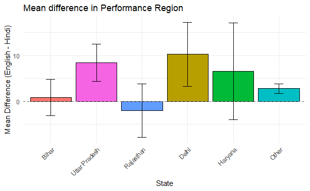

```r
df_lived <- df_region %>%
  filter(!is.na(Living_Yr)) %>%
  mutate(Living_Years_Split = if_else(Living_Yr <= median(Living_Yr, na.rm = TRUE),
                                      "Below Median", "Above Median"))

region_split_keys <- df_lived %>% distinct(State_Grouped, Living_Years_Split)

region_lived_boot <- region_split_keys %>%
  group_split(State_Grouped, Living_Years_Split) %>%
  purrr::map_dfr(function(g) {
    state <- unique(g$State_Grouped)
    split <- unique(g$Living_Years_Split)
    subset_data <- df_lived %>% filter(State_Grouped == state, Living_Years_Split == split)
    if (length(unique(subset_data$Language)) == 2 && nrow(subset_data) >= 10) {
      b <- boot(data = subset_data, statistic = bootstrap_diff, R = 1000)
      tibble(State = state, Split = split,
             diff = mean(subset_data$num_total_answers[subset_data$Language == "English"], na.rm = TRUE) -
                    mean(subset_data$num_total_answers[subset_data$Language == "Hindi"], na.rm = TRUE),
             se_diff = sd(b$t))
    } else {
      tibble(State = state, Split = split, diff = NA, se_diff = NA)
    }
  }) %>%
  left_join(indian_states %>% select(`State/UT`, Latitude), by = c("State" = "State/UT")) %>%
  mutate(Distance_to_Equator = abs(Latitude),
         Split = factor(Split, levels = c("Below Median", "Above Median")))

plot4 <- ggplot(region_lived_boot, aes(x = reorder(State, Distance_to_Equator), y = diff, fill = Split)) +
  geom_col(position = position_dodge(width = 0.7), color = "black", width = 0.6) +
  geom_errorbar(aes(ymin = diff - se_diff, ymax = diff + se_diff),
                width = 0.2, position = position_dodge(width = 0.7)) +
  geom_hline(yintercept = 0, linetype = "dashed", color = "grey40") +
  scale_fill_manual(values = c("Below Median" = "#a1d99b", "Above Median" = "#006d2c")) +
  theme_minimal() +
  labs(x = "State", y = "Mean Difference (English - Hindi)",
       title = "Mean difference in Performance by Years Lived in Region", fill = "Years Lived") +
  theme(axis.text.x = element_text(angle = 45, hjust = 1))

print(plot3)
```

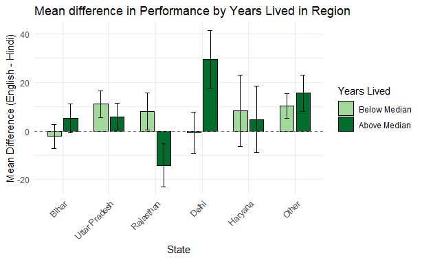

```r
print(plot4)
```

# Final Plots

This section exports the final sets of visualisations as PDF files for presentation or publication.

```r
# Save combined plots
pdf("Figures/Bilingual_Study_Graphs_Income.pdf", width = 11, height = 8.5)
grid.arrange(plot1, plot2 ,ncol = 1)
dev.off()
```

```r
pdf("Figures/Bilingual_Study_Graphs_Region.pdf", width = 11, height = 8.5)
```

```r
grid.arrange(plot3, plot4 ,ncol = 1)
dev.off()
```

```r
pdf("Figures/Bilingual_Income_SES_Distribution.pdf", , width = 11, height = 8.5)
```

```r
print(ses_frac_plot)
dev.off
```

[output not shown]